# Data Mining / Prospeção de Dados

## Diogo Soares and Sara C. Madeira, 2020/21

# Project 1 - Pattern Mining

## Team Identification

**GROUP PD03**

Students:

- **Eduardo Carvalho - nº55881**
- **Filipe Santos - nº55142**
- **Ivo Oliveira - nº50301**

# Notes

> *As we'll describe more indepth further down, we limited some databases as they were too computing intensive.*

> *Given the huge amount of calculations and its computing needs, we had to do some externally, outside of the Jupyter notebook as we we quickly found that Google Colab — The tool we used, lacked the sufficient RAM. Given this, in some sections the output is given as an image (printscreen) of the code being ran externally. However the code used will be above.*

> It is mandatory to install mlxtend to run the code, however pip install works differently in Google Colab, the correct command is: `!pip install mlxtend --upgrade`

> > *The project files can also be found here: https://github.com/iamemc/PD_01*

### 1.1. Load and Preprocess Data

**Product quantities were not considered.**

## Limitations

*Due to a problem in the database quantity (QTY) column, the SessionID that corresponds to an equivalent ID in Buys, was thus considered as a purchase. Altough this skews the expected results, the fact some buys had quantities of 0 and other problems, this was a temporarly, yet accurate metric of products and their given clicks and purchases*

*We also add to limit the database being loaded, namely store-clicks.dat, which we only took into account the top 50% of it. This will skew the results but we believe that not only was it acceptable and necessary, considering how big the database is, we can still find useful info.*

```python
#!pip install mlxtend
!pip install mlxtend --upgrade

import pandas as pd
import numpy as np
import csv
import matplotlib.pyplot as plt
from matplotlib.collections import QuadMesh
from matplotlib.text import Text
from matplotlib.colors import LogNorm
import seaborn as sns
import tkinter as tkr
from mlxtend.preprocessing import  TransactionEncoder
from mlxtend.frequent_patterns import apriori
from mlxtend.frequent_patterns import association_rules
from mlxtend.frequent_patterns import fpgrowth
from mlxtend.frequent_patterns import fpmax
```

```python
from google.colab import drive
drive.mount('/content/drive')
```

```python
products=pd.read_csv('/content/drive/MyDrive/Datasets/projetoPD/products.csv',
                     header=None,
                     names=['ItemID','Category'],
                     dtype={'ItemID': np.int32, 'Category':str})
buys=pd.read_csv('/content/drive/MyDrive/Datasets/projetoPD/store-buys.dat',
                 header=None,
                 names=['SessionID','TimeStamp','ItemID','Price','Qty'],
                 dtype={'SessionID':np.int32, 'TimeStamp':str, 'ItemID': np.int32,
                        'Price':np.int16, 'Qty':'category'})
clicks=pd.read_csv('/content/drive/MyDrive/Datasets/projetoPD/store-clicks.dat',
                   header=None,
                   nrows=10352280,
                   names=['SessionID','TimeStamp','ItemID','Context'],
                   dtype={'SessionID':np.int32, 'TimeStamp':str, 'ItemID': np.int32,
                        'Context':'category'})
```

```python
buys = buys.drop(columns=['Qty'])
products.memory_usage(deep=True)
buys.memory_usage(deep=True)
clicks.memory_usage(deep=True)
```

```
Index              128
SessionID     41409120
TimeStamp    838534680
ItemID        41409120
Context       10352338
dtype: int64
```

# Database Corrections

> *This code segment contains Database corrections of the following:*
> > - *products_no_duplicates - removed duplicates*
> > - *buys_upd - added product names & season*

```python
"""
DATABASE CORRECTIONS
products_no_duplicates - removed duplicates
buys_upd - added product names & season
"""
products_no_duplicates = products.drop_duplicates().reset_index(drop=True)

buys_upd =pd.merge(buys,products_no_duplicates)
clicks_upd= pd.merge(clicks,products_no_duplicates)

#ignore prices/quantities of 0
#buys_upd = buys_upd[buys_upd.Price>0]
#buys_upd = buys_upd[buys_upd.Qty>0]
#no click_upd ver context=0 (missing value)

product_name_buys=[]
for cat in buys_upd.Category:
  product_name_buys.append(cat.split('.')[-1].replace('_',' ').title())
product_name_clicks=[]
for cat in clicks_upd.Category:
  product_name_clicks.append(cat.split('.')[-1].replace('_',' ').title())
#product_name[:5]

buys_upd['ProductName']= product_name_buys
buys_upd = buys_upd.drop('Category', axis=1)
clicks_upd['ProductName']=product_name_clicks
clicks_upd=clicks_upd.drop('Category', axis=1)

dates_buys =[]
season_buys =[]
dates_clicks =[]
season_clicks =[]

for i in buys_upd["TimeStamp"]:
  dates_buys.append(i[:10])
  if i[5:7] == "04" or i[5:7] == "05":
     season_buys.append("Spring")
  elif i[5:7] == "06" or i[5:7] == "07":
    season_buys.append("Summer")
  else:
    season_buys.append("Other")

for i in clicks_upd["TimeStamp"]:
  dates_clicks.append(i[:10])
  if i[5:7] == "04" or i[5:7] == "05":
     season_clicks.append("Spring")
  elif i[5:7] == "06" or i[5:7] == "07":
    season_clicks.append("Summer")
  else:
    season_clicks.append("Other")

weekday_buys=[]
buys_upd["TimeStamp"] = pd.to_datetime(buys_upd["TimeStamp"])
buys_upd["Weekday_Num"]=buys_upd["TimeStamp"].dt.dayofweek
for i in buys_upd["Weekday_Num"]:
  if i < 5:
    weekday_buys.append("Weekday")
  else:
    weekday_buys.append("Weekend")

weekday_clicks=[]
clicks_upd["TimeStamp"] = pd.to_datetime(clicks_upd["TimeStamp"])
clicks_upd["Weekday_Num"]=clicks_upd["TimeStamp"].dt.dayofweek
for i in clicks_upd["Weekday_Num"]:
  if i < 5:
    weekday_clicks.append("Weekday")
  else :
    weekday_clicks.append("Weekend")

buys_upd = buys_upd.drop(columns=['TimeStamp'])
buys_upd.insert(1, "TimeStamp", dates_buys)
buys_upd["Season"] = season_buys
buys_upd["Weekday"] = weekday_buys
buys_upd.sort_values(by='TimeStamp')

clicks_upd = clicks_upd.drop(columns=['TimeStamp'])
clicks_upd.insert(1, "TimeStamp", dates_clicks)
clicks_upd["Season"] = season_clicks
clicks_upd["Weekday"] = weekday_clicks
buys_upd=buys_upd.sort_values(by='SessionID').reset_index(drop=True)
```

```python
buys_upd=buys_upd.drop_duplicates().reset_index(drop=True)
len(buys)-len(buys.drop_duplicates())
```

```
113
```

```python
buys_upd=buys_upd.drop_duplicates().reset_index(drop=True)
clicks_upd=clicks_upd.sort_values(by='SessionID').reset_index(drop=True)
```

> *The store clicks database has 23 duplicates, which have to be removed for further analysis.*

```python
clicks_upd=clicks_upd.drop_duplicates().reset_index(drop=True)
len(clicks)-len(clicks.drop_duplicates())
```

```
23
```

# Most interesting items?

## Most Clicked Products

```python
# What are the most interesting items? (most clicked)
most_clicks = clicks_upd.groupby(["ProductName"], as_index=False).count().sort_values(by="SessionID", ascending=False)
most_clicks = most_clicks[['ProductName','SessionID']].reset_index(drop=True)
most_clicks = most_clicks.rename(columns={'SessionID':'Clicks'})
most_clicks.index += 1
print("Table 1.")
most_clicks.head(10)
```

```
Table 1.
```

|  | ProductName | Clicks |
| --- | --- | --- |
| 1 | Tennis | 664834 |
| 2 | Memory | 494996 |
| 3 | Toster | 343325 |
| 4 | Blender | 331917 |
| 5 | Notebook | 209466 |
| 6 | Meat Grinder | 209409 |
| 7 | Monitor | 208220 |
| 8 | Iron | 171817 |
| 9 | Vacuum | 160518 |
| 10 | Bag | 158312 |

> *The top three most clicked products are Tennis related poducts, with a total of 664834, followed by Memory chips with 494996 and lastly, Tosters with 343325.*

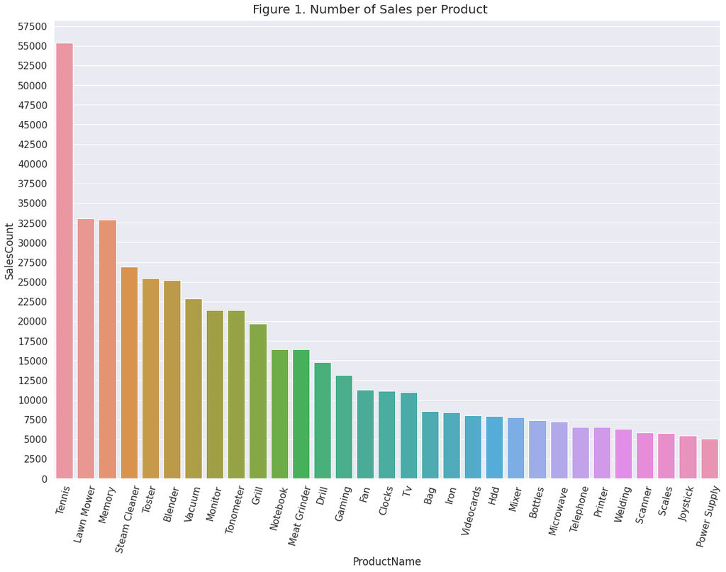

```python
#2. What are the most bought products?
quantities = buys_upd.groupby(["ProductName"], as_index=False).count().sort_values(by="SessionID", ascending=False)
quantities2 = quantities
quantities = quantities[['ProductName','SessionID']].reset_index(drop=True)
quantities = quantities.rename(columns={'SessionID':'SalesCount'})
quantities.index += 1

quantities = quantities[quantities.SalesCount>5000]
most_bought = sns.catplot(x="ProductName", y="SalesCount", kind="bar", data = quantities)
most_bought.fig.suptitle('Figure 1. Number of Sales per Product')
for ax in most_bought.axes.flat:
    for label in ax.get_xticklabels():
        label.set_rotation(75)
most_bought.set(yticks=np.arange(0,60000,2500))
most_bought.fig.set_figheight(12.5)
most_bought.fig.set_figwidth(25)
```

> **Products Sales per day of the Week - Heat Map.**

```python
#prepare graph info
quantities2 = buys_upd
quantities2['SessionID'] = 1
daysofWeek={0:'Segunda-Feira',1:'Terça-Feira',2:'Quarta-Feira',3:'Quinta-Feira', 4:'Sexta-Feira',5:'Sábado',6:'Domingo'}
quantities2['Weekday_Num'] = quantities2['Weekday_Num'].map(daysofWeek)
quantities2 = quantities2.groupby(["Weekday_Num","ProductName"], as_index=False)['SessionID'].sum()

drop_column = quantities2.groupby(['ProductName'], as_index=False)['SessionID'].sum()
drop_column = drop_column.sort_values(by='SessionID', ascending=False)
drop_column = drop_column.tail(-20)
drop_column = drop_column['ProductName']

quantities2 = quantities2[~quantities2['ProductName'].isin(drop_column)]
quantities2 = quantities2.sort_values(by='SessionID', ascending=False).reset_index(drop=True)
quantities2 = quantities2.pivot_table(index='Weekday_Num', columns = 'ProductName')['SessionID']
quantities2 = quantities2.reindex(['Segunda-Feira','Terça-Feira', 'Quarta-Feira','Quinta-Feira', 'Sexta-Feira','Sábado','Domingo'])
# ----- get max & min values for graph
hm_vmax = quantities2.max()
hm_vmax = hm_vmax.max()
hm_vmin = quantities2.min()
hm_vmin = hm_vmin.min()
quantities2['Total'] = quantities2.sum(axis=1)
```

[figure not shown]

```python
#process data for heatmap graph
sns.set(font_scale = 1.4)
fig, ax = plt.subplots(figsize=(30,10))
plt.suptitle("Product clicks per day of the week")
sns.heatmap(quantities2, cmap='coolwarm', square=True, linewidths=1, annot=True, fmt="d", vmin=hm_vmin*2, vmax=hm_vmax/2.5)
quadmesh = ax.findobj(QuadMesh)[0] # get array of colors
facecolors = quadmesh.get_facecolors()
facecolors[np.arange(20,147,21)] = np.array([1,1,1,1]) # make colors of the last column white
quadmesh.set_facecolors = facecolors # set modified colors
for i in ax.findobj(Text): # set color of all text to black
    i.set_color('black')
```

> *Above is an heat map analysis of the 20 most sold products (sorted alphabetically) and their sales per day of the week. This visualization goes on pair with the previous bar graph, and in it we can see the sales dispersion clearly. On the rightmost column is the total number of sales per day.*

> > *Sunday is by far the most popular day, with a total of 108688 sales and with the cells with the higher numbers. Tennis products bought at Sundays which number 16159 are the combination with the higher count.*

> > *Besides Sundays, Mondays and Saturdays are the most popular days of the week to buy online with 73945 and 62177 purchases, respectively. On the opposite end, Tuesday is is the least popular day, with only 19752 purchases.*

> > *As shown before, Tennis products are the most popular, and this is true for any day of the week compared to other products within the same day.*

## 1.2. Compute Frequent Itemsets

> *Due to restraints in processing power, some of the computing was done outside Google Colab, due to this the respective prints and subsequent analysis will be provided and the used code will be posted.*

> *For sake of performance, it was decided to only use fpgrowth as it was the fastest option, as well as using less memory than apriori. From our tests, the result difference was negligenciable*

```python
#Setting up: Which products are bought together?
all_sessions_buy={}
for i in range(len(buys_upd)):
  all_sessions_buy[buys_upd.SessionID[i]]=[]
for i in range(len(buys_upd)):
  if buys_upd.ProductName[i] not in all_sessions_buy.get(buys_upd.SessionID[i]):
    all_sessions_buy[buys_upd.SessionID[i]].append(buys_upd.ProductName[i])

transactions_buy=list(all_sessions_buy.values())
```

```python
#Setting up: Which products are viewed together?
all_sessions_click={}
for i in range(len(clicks_upd)):
  all_sessions_click[clicks_upd.SessionID[i]]=[]
for i in range(len(clicks_upd)):
  if clicks_upd.ProductName[i] not in all_sessions_click.get(clicks_upd.SessionID[i]):
    all_sessions_click[clicks_upd.SessionID[i]].append(clicks_upd.ProductName[i])

transactions_click=list(all_sessions_click.values())
```

```python
#Compute binary databases
tr_enc = TransactionEncoder()
#buys
trans_array_buy = tr_enc.fit(transactions_buy).transform(transactions_buy)
binary_database_buy = pd.DataFrame(trans_array_buy, columns = tr_enc.columns_)
#clicks
trans_array_click = tr_enc.fit(transactions_click).transform(transactions_click)
binary_database_click = pd.DataFrame(trans_array_click, columns = tr_enc.columns_)
```

## Frequent most bought itemsets considering a minimum support of 1%.

> *As already stated, we decided to use fp-Growth as it's performance for large databases is better than apriori.* *This is supported by academic research as one of the most commonly used algorithms for finding frequent itemsets while being less performance intensive.*

> *We'd like to refer to this paper for research comparisons and choice reasoning:* https://www.researchgate.net/figure/Comparison-of-Apriori-Eclat-and-FP-Growth-algorithm-on-artificial-dataset-when-the_fig2_272864559

```python
#FP-Growth é melhori que apriori
#buys
frequent_itemsets_fpg_buy = fpgrowth(binary_database_buy, min_support=0.01, use_colnames=True)
frequent_itemsets_fpg_buy['length'] = frequent_itemsets_fpg_buy['itemsets'].apply(lambda x: len(x))
frequent_itemsets_fpg_buy.sort_values(by='support', ascending=False).reset_index()
```

> **Products Sales - Ordered by Support.**

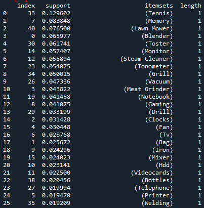

> *As seen in the image above, Tennis products are the most commonly bought single products with 13% Support. Memory Chips are the second with 8% and closely Lawn Mowers with 7.6%.*

```python
frequent_itemsets_fpg_buy.sort_values(by='length', ascending=False).reset_index()
```

> **Products Sales - Ordered by Length.**

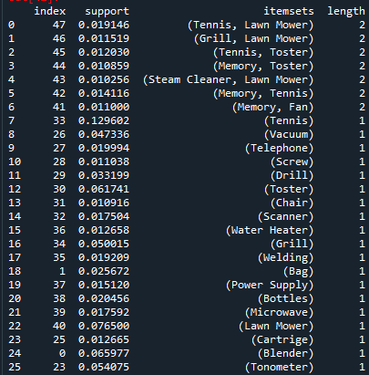

**Products Clicks - Ordered by Support and Length >= 2.**

```python
frequent_itemsets_fpg_clicks = fpgrowth(binary_database_click, min_support=0.01, use_colnames=True)
frequent_itemsets_fpg_clicks['length'] = frequent_itemsets_fpg_clicks['itemsets'].apply(lambda x: len(x))
frequent_itemsets_fpg_clicks.sort_values(by='length', ascending=False).reset_index()
frequent_itemsets_fpg_clicks[(frequent_itemsets_fpg_clicks['support'] >= 0.01) & (frequent_itemsets_fpg_clicks['length'] >= 2)].sort_values(by='length', ascending=False).reset_index()
```

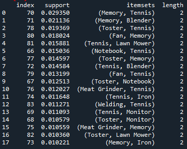

> *Interestingly, the most clicked itemsets are not the same as the most bought ones. Memory Chips and Tennis products are the most often clicked per user session with the highest Support of 2.9%. Memory Chips and Blenders are also highly clicked together with 2.1% Support. Followed by Tosters and Tennis with 1.9% Support.*

> *In contrast with the most bought together products: Tennis and Lawn Mowers, these only appear in the 5th most clicked, with a Support of 1.5%.*

### Association Rules from Frequent Itemsets

- Generate association rules with a choosed value (C) for minimum confidence.
- Generate association rules with a choosed value (L) for minimum lift.
- Generate association rules with both confidence >= C% and lift >= L.
- Change C and L when it makes sense and discuss the results.

```python
# Generate association rules with confidence >= 90%
rules_buy = association_rules(frequent_itemsets_fpg_buy, metric = "confidence", min_threshold=0.10)
rules_buy_lift = association_rules(frequent_itemsets_fpg_buy, metric="lift", min_threshold=1.2)
rules_buy_lift[(rules_buy_lift['lift'] >= 2)].sort_values(by='lift', ascending=False).reset_index()
rules_buy
```

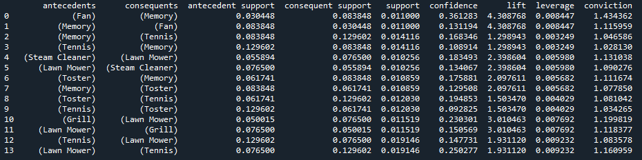

> *At first a minimum Lift threshold of 1.2 was used, however this proved to be a few too many, which will be explored below.*

> *However we can denote a few items that are closely bought together, namely Fans and Memory chips, which overall display the higher confidence, lift and conviction. Altough the support isn't the highest, that is, the given pair doesn't appear that often in the baskets, when they do, they have a strong correlation.*

**Products Sales - Ordered by Lift and Higher Confidence**

> **Rules:**
> - Lift >= 2
> - Confidence >= 15%

```python
rules_buy_lift[(rules_buy_lift['confidence'] >= 0.15) & (rules_buy_lift['lift'] >= 2)].sort_values(by='lift', ascending=False).reset_index()
```

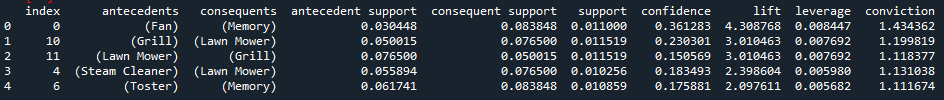

> *With higher thresholds than the previous output, we can demonstrate more closely related items.*

> *Note that grills and Lawn Mowers climbed to 2nd placed given the new criteria.*

> > *It should be noted that most of the output, except for Grills and Lawn Mowers, is almost identical to the previous one the same except for fewer items that were filtered, but as it was sorted previously, the top itemsets were kept.* *These top itemsets are the ones we're iterested at, as they are the most commonly bought together, which a store manager or marketing department could take advantage of if discounts or similar promotions are considered in the future.*

> > *A few things to take in mind is that many outdoor related items are bought, as given the high range of categories provided, this category should be given the most attention of marketing team.*

**Clicks per Session - Ordered by Lift**

```python
rules_clicks_lift = association_rules(frequent_itemsets_fpg_clicks, metric="lift", min_threshold=1.2)
rules_clicks_lift[(rules_clicks_lift['lift'] >= 2)].sort_values(by='lift', ascending=False).reset_index()
```

[figure not shown]

```python
rules_buy_lift[(rules_buy_lift['confidence'] >= 0.20) & (rules_buy_lift['lift'] >= 2)].sort_values(by='lift', ascending=False).reset_index()
```

[figure not shown]

### Maximal Patterns: Compute Maximal Frequent Itemsets

> *Maximal Frequent Itemsets are frequent itemsets without a frequent superset. Thus, by generating only maximal frequent itemsets we can reduce the number of itemsets calculated and also the time needed for the generation of said itemsets as each maximal itemset implies the presence of same length itemsets. As most previous calculation of Frequent Itemsets have been very performance intensive, Maximal Frequent Itemsets have proven to be quite fast and reliable*

**Maximal bought itemsets - Ordered by Support**

> **Rules:**
> - Support > 1%

```python
rules_buy_fmax = fpmax(binary_database_buy, min_support=0.01, use_colnames=True)
rules_buy_fmax['length'] = rules_buy_fmax['itemsets'].apply(lambda x: len(x))
rules_buy_fmax.sort_values(by='support', ascending=False).reset_index()
```

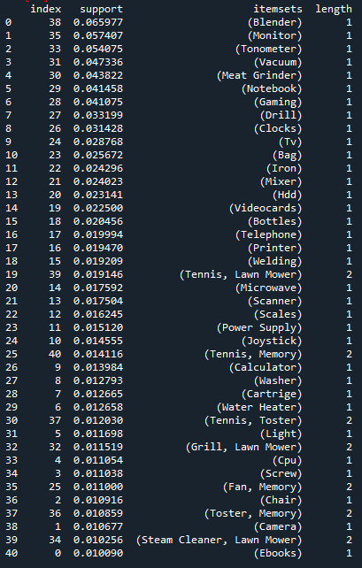

> *In the above image we can see all the Maximal Frequent Itemsets above 1% threshold of the store-buys.dat database however the ones with most support are single item which for the purpose of this report we'll discard in favor of >= 2, which we'll discuss next. However we should point the novelty appearance of some products, like Monitors, with 5.7% Support, Tonometers and Vacuums, with 5.4 and 4.7 percent, respectively.*

**Maximal bought itemsets - Ordered by Support**

> **Rules:**
> - Length >= 2
> - Support > 1%

```python
rules_buy_fmax[(rules_buy_fmax['length'] >= 2)].sort_values(by='support', ascending=False).reset_index()
```

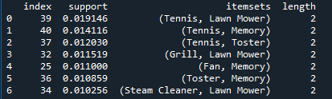

> *If we filter the previous list with itemsets of length equal or greater than 2, we can see that previously mined frequent itemsets (refering to FP-Growth section) are still true when using the FPmax algorithm.*

> *The previous assumption that Tennis products are the most bought and most commonly bought together with other products still stands true.*

**Maximal clicked itemsets - Ordered by Support**

> **Rules:**
> - Length >= 2
> - Support > 1%

```python
rules_clicks_fmax = fpmax(binary_database_click, min_support=0.01, use_colnames=True)
rules_clicks_fmax['length'] = rules_clicks_fmax['itemsets'].apply(lambda x: len(x))
rules_clicks_fmax[(rules_clicks_fmax['length'] >= 2)].sort_values(by='support', ascending=False).reset_index()
```

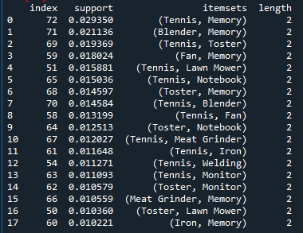

> *As an extension to the previous purchase analysis, the above image displays the clicked items and respective itemsets found using FP-Max*

> *Some changes can be found when comparing with the most bought itemsets found, for example:*
> - *Tennis and Lawn Mower, the most bought items previously mined are only the 5th most clicked pair*
> - *The Tennis and Memory chips are still the most clicked with a support of 2.9%, which we've already previously found using other algorithms.*

> *All in all, the most clicked itemsets using FP-Max are about the same as the ones previously found.*

### Conclusions

> *As previously discussed, the apriori algorithm was discarded as a possibility due to it's high cost of performance. We chose FP-Growth as the base to analyze frequent itemsets of both clicks and purchases.*

> *A few interesting points is that the most clicked items and respective itemsets are not the same as the ones being bought, with Fans, Monitors and Tosters usually appearing in the top 5 of all our findings, unlike the top purchased items that as said, are usually outdoor related.*

> *As seen in the Heat Map of sales of most sold products, the Weekend is usually the busiest day, as was to be expected. Curiously, Mondays are busier than Saturdays. We believe the Heat Map to be an interesting overall analysis of the database, as not only does it show the most single sold item, it also shows when, which in the future could be used for more targeted marketing and stock management*

> *It's also curious how small the Support threshold had to be in all of our computations, as any value higher than 2 was given back as empty. However considering how large the database is, both in the number of products sold and the sale number, we believe this is because of sales entropy and noise.*

# 2. Week vs Weekend Purchases

### 2.1. Load and Preprocess Data

**Product quantities should not be considered.**

```python
#dividing each dataset in weekend (we) sessions and workday (wd) ones
buys_upd_wd=buys_upd[buys_upd["Weekday_Num"]<5]
buys_upd_we=buys_upd[buys_upd["Weekday_Num"]>=5]
clicks_upd_wd=clicks_upd[clicks_upd["Weekday_Num"]<5]
clicks_upd_we=clicks_upd[clicks_upd["Weekday_Num"]>=5]
clicks_upd_wd=clicks_upd_wd.sort_values(by='SessionID').reset_index(drop=True)
clicks_upd_we=clicks_upd_we.sort_values(by='SessionID').reset_index(drop=True)
buys_upd_wd=buys_upd_wd.sort_values(by='SessionID').reset_index(drop=True)
buys_upd_we=buys_upd_we.sort_values(by='SessionID').reset_index(drop=True)
```

**The most interesting products are the same during the week and the weekend?**

```python
most_clicks_wd = clicks_upd_wd.groupby(["ProductName"], as_index=False).count().sort_values(by="SessionID", ascending=False)
most_clicks_we = clicks_upd_we.groupby(["ProductName"], as_index=False).count().sort_values(by="SessionID", ascending=False)
most_clicks_wd = most_clicks_wd[['ProductName','SessionID']].reset_index(drop=True)
most_clicks_wd = most_clicks_wd.rename(columns={'SessionID':'Clicks'})
most_clicks_wd.index += 1

most_clicks_we = most_clicks_we[['ProductName','SessionID']].reset_index(drop=True)
most_clicks_we = most_clicks_we.rename(columns={'SessionID':'Clicks'})
most_clicks_we.index += 1

most_clicks_wd.head(10)
```

|  | ProductName | Clicks |
| --- | --- | --- |
| 1 | Tennis | 425741 |
| 2 | Memory | 310743 |
| 3 | Blender | 232367 |
| 4 | Toster | 212974 |
| 5 | Meat Grinder | 147274 |
| 6 | Notebook | 140351 |
| 7 | Monitor | 135662 |
| 8 | Iron | 123656 |
| 9 | Bag | 112340 |
| 10 | Vacuum | 109872 |

```python
most_clicks_we.head(10)
```

|  | ProductName | Clicks |
| --- | --- | --- |
| 1 | Tennis | 239093 |
| 2 | Memory | 184253 |
| 3 | Toster | 130351 |
| 4 | Blender | 99550 |
| 5 | Monitor | 72558 |
| 6 | Notebook | 69115 |
| 7 | Meat Grinder | 62135 |
| 8 | Fan | 61298 |
| 9 | Vacuum | 50646 |
| 10 | Lawn Mower | 48358 |

> *The first 2 most popular items are the same in both the weekend's and workday's data . The third most popular single item during the workdays is the (Blender) while in the weekend is the (Toster).*

**What are the most bought products during the week? And during the weekend?**

```python
most_sold_wd = buys_upd_wd.groupby(["ProductName"], as_index=False).count().sort_values(by="SessionID", ascending=False)
most_sold_wd = most_sold_wd[['ProductName','SessionID']].reset_index(drop=True)
most_sold_wd = most_sold_wd.rename(columns={'SessionID':'SalesCount'})
most_sold_wd.index += 1

most_sold_we = buys_upd_we.groupby(["ProductName"], as_index=False).count().sort_values(by="SessionID", ascending=False)
most_sold_we = most_sold_we[['ProductName','SessionID']].reset_index(drop=True)
most_sold_we = most_sold_we.rename(columns={'SessionID':'SalesCount'})
most_sold_we.index += 1
most_sold_wd.head(10)
```

|  | ProductName | SalesCount |
| --- | --- | --- |
| 1 | Tennis | 29747 |
| 2 | Memory | 18296 |
| 3 | Lawn Mower | 17197 |
| 4 | Blender | 15507 |
| 5 | Steam Cleaner | 14348 |
| 6 | Toster | 13409 |
| 7 | Monitor | 12705 |
| 8 | Tonometer | 12601 |
| 9 | Vacuum | 11671 |
| 10 | Gaming | 11103 |

```python
most_sold_we.head(10)
```

|  | ProductName | SalesCount |
| --- | --- | --- |
| 1 | Tennis | 25649 |
| 2 | Lawn Mower | 15864 |
| 3 | Memory | 14607 |
| 4 | Steam Cleaner | 12536 |
| 5 | Toster | 12054 |
| 6 | Vacuum | 11199 |
| 7 | Blender | 9693 |
| 8 | Grill | 9082 |
| 9 | Tonometer | 8811 |
| 10 | Monitor | 8712 |

> *The three top items sold individually is the same during the workdays and the weekend . At this point what kind of items is sold individually doesn't seem to be influenced by the day of the week.*

### 2.2. Compute Frequent Itemsets

> *We varied the support metric in the FPGrowth process to see the difference in outputs. Using support = 5% leads to no relevant itemsets with length greater than 1 so to explore which products are clicked/bought together we must lower the minimal support.*

> *Using support = 0.5% we obtained 2-itemsets for both store-buys and store-clicks, in the weekend and in workdays , we also obtained 3-itemsets for the weekend data but their support was so low that no credible conclusion could be obtained.*

> *We decided to continue our analysis with minimal support = 1% because that way we could analyze 2-itemsets while also cutting down irrelevant information brought by a lower minimal support.*

> *We also tried a minimal support < 0.5% which crashed the run due to the impossibility of allocation of memory necessary to subdue the store-clicks data set to FPGrowth.*

> *We used the mlxtends association_rules function to obtain strong association rules between frequent itemsets for each dataset.*

> *Since lift takes into account the overall populary of the antecedent itemsets is is a better metric to determine association rules’ streght, so after some consideration we considered strong the association rules with lift >=1.5 and obviously support >= 1%. We selected only associations with lift far from 1.*

```python
#binary databases -- buys
#workday-buys
all_sessions_buy_wd={}
for i in range(len(buys_upd_wd)):
  all_sessions_buy_wd[buys_upd_wd.SessionID[i]]=[]

for i in range(len(buys_upd_wd)):
  if buys_upd_wd.ProductName[i] not in all_sessions_buy_wd.get(buys_upd_wd.SessionID[i]):
    all_sessions_buy_wd[buys_upd_wd.SessionID[i]].append(buys_upd_wd.ProductName[i])

transactions_buy_wd=list(all_sessions_buy_wd.values())

tr_enc = TransactionEncoder()
trans_array_buy_wd = tr_enc.fit(transactions_buy_wd).transform(transactions_buy_wd)
binary_database_buy_wd = pd.DataFrame(trans_array_buy_wd, columns=tr_enc.columns_)

#weekend-buys
all_sessions_buy_we={}
for i in range(len(buys_upd_we)):
  all_sessions_buy_we[buys_upd_we.SessionID[i]]=[]

for i in range(len(buys_upd_we)):
  if buys_upd_we.ProductName[i] not in all_sessions_buy_we.get(buys_upd_we.SessionID[i]):
    all_sessions_buy_we[buys_upd_we.SessionID[i]].append(buys_upd_we.ProductName[i])

transactions_buy_we=list(all_sessions_buy_we.values())

trans_array_buy_we = tr_enc.fit(transactions_buy_we).transform(transactions_buy_we)
binary_database_buy_we = pd.DataFrame(trans_array_buy_we, columns=tr_enc.columns_)

#binary databases -- clicks
#workday-clicks
all_sessions_clicks_wd={}
for i in range(len(clicks_upd_wd)):
  all_sessions_clicks_wd[clicks_upd_wd.SessionID[i]]=[]

for i in range(len(clicks_upd_wd)):
  if clicks_upd_wd.ProductName[i] not in all_sessions_clicks_wd.get(clicks_upd_wd.SessionID[i]):
    all_sessions_clicks_wd[clicks_upd_wd.SessionID[i]].append(clicks_upd_wd.ProductName[i])

transactions_clicks_wd=list(all_sessions_clicks_wd.values())

trans_array_clicks_wd = tr_enc.fit(transactions_clicks_wd).transform(transactions_clicks_wd)
binary_database_clicks_wd = pd.DataFrame(trans_array_clicks_wd, columns=tr_enc.columns_)

#weekends-clicks
all_sessions_clicks_we={}
for i in range(len(clicks_upd_we)):
  all_sessions_clicks_we[clicks_upd_we.SessionID[i]]=[]

for i in range(len(clicks_upd_we)):
  if clicks_upd_we.ProductName[i] not in all_sessions_clicks_we.get(clicks_upd_we.SessionID[i]):
    all_sessions_clicks_we[clicks_upd_we.SessionID[i]].append(clicks_upd_we.ProductName[i])

transactions_clicks_we=list(all_sessions_clicks_we.values())

trans_array_clicks_we = tr_enc.fit(transactions_clicks_we).transform(transactions_clicks_we)
binary_database_clicks_we = pd.DataFrame(trans_array_clicks_we, columns=tr_enc.columns_)
```

**Frequent itemsets with minimal support = 0.01 for store-clicks on workdays:**

```python
frequent_itemsets_clicks_wd = fpgrowth(binary_database_clicks_wd, min_support=0.01, use_colnames=True)
frequent_itemsets_clicks_wd= frequent_itemsets_clicks_wd.sort_values(by='support',ascending=False).reset_index(drop=True)
frequent_itemsets_clicks_wd['length'] = frequent_itemsets_clicks_wd['itemsets'].apply(lambda x: len(x))
frequent_1_itemsets_clicks_wd = frequent_itemsets_clicks_wd[frequent_itemsets_clicks_wd['length'] == 1].sort_values(by='support',ascending=False).reset_index(drop=True)
frequent_2_itemsets_clicks_wd = frequent_itemsets_clicks_wd[frequent_itemsets_clicks_wd['length'] == 2].sort_values(by='support',ascending=False).reset_index(drop=True)
frequent_3_itemsets_clicks_wd = frequent_itemsets_clicks_wd[frequent_itemsets_clicks_wd['length'] == 3].sort_values(by='support',ascending=False).reset_index(drop=True)#nao tem

print(frequent_1_itemsets_clicks_wd.head(10))
```

```
    support        itemsets  length
0  0.169897        (Tennis)       1
1  0.126707        (Memory)       1
2  0.096897       (Blender)       1
3  0.083335        (Toster)       1
4  0.066122  (Meat Grinder)       1
5  0.062214      (Notebook)       1
6  0.057255       (Monitor)       1
7  0.053632          (Iron)       1
8  0.051161           (Bag)       1
9  0.046057     (Telephone)       1
```

```python
print(frequent_2_itemsets_clicks_wd.head(10))
```

```
    support                itemsets  length
0  0.025497        (Tennis, Memory)       2
1  0.019337       (Blender, Memory)       2
2  0.016686        (Tennis, Toster)       2
3  0.014896           (Memory, Fan)       2
4  0.013815      (Notebook, Tennis)       2
5  0.013651       (Tennis, Blender)       2
6  0.012721        (Memory, Toster)       2
7  0.012338    (Tennis, Lawn Mower)       2
8  0.011396       (Tennis, Welding)       2
9  0.011365  (Tennis, Meat Grinder)       2
```

**Frequent itemsets with minimal support = 0.01 for store-clicks on weekends:**

```python
frequent_itemsets_clicks_we = fpgrowth(binary_database_clicks_we, min_support=0.01, use_colnames=True)
frequent_itemsets_clicks_we= frequent_itemsets_clicks_we.sort_values(by='support',ascending=False).reset_index(drop=True)
frequent_itemsets_clicks_we['length'] = frequent_itemsets_clicks_we['itemsets'].apply(lambda x: len(x))
frequent_1_itemsets_clicks_we = frequent_itemsets_clicks_we[frequent_itemsets_clicks_we['length'] == 1].sort_values(by='support',ascending=False).reset_index(drop=True)
frequent_2_itemsets_clicks_we = frequent_itemsets_clicks_we[frequent_itemsets_clicks_we['length'] == 2].sort_values(by='support',ascending=False).reset_index(drop=True)
frequent_3_itemsets_clicks_we = frequent_itemsets_clicks_we[frequent_itemsets_clicks_we['length'] == 3].sort_values(by='support',ascending=False).reset_index(drop=True)#nao tem
print(frequent_1_itemsets_clicks_we.head(10))
```

```
    support        itemsets  length
0  0.202100        (Tennis)       1
1  0.160405        (Memory)       1
2  0.110311        (Toster)       1
3  0.091753       (Blender)       1
4  0.067627      (Notebook)       1
5  0.067269       (Monitor)       1
6  0.062043  (Meat Grinder)       1
7  0.061708           (Fan)       1
8  0.048108    (Lawn Mower)       1
9  0.047720     (Telephone)       1
```

```python
print(frequent_2_itemsets_clicks_we.head(10))
```

```
    support              itemsets  length
0  0.037918      (Tennis, Memory)       2
1  0.025335      (Tennis, Toster)       2
2  0.025126     (Blender, Memory)       2
3  0.024987         (Memory, Fan)       2
4  0.023763  (Tennis, Lawn Mower)       2
5  0.018768      (Memory, Toster)       2
6  0.018222         (Tennis, Fan)       2
7  0.017748    (Notebook, Tennis)       2
8  0.016647     (Tennis, Blender)       2
9  0.015716    (Notebook, Toster)       2
```

**Frequent itemsets with minimal support = 0.01 for store-buys on workdays:**

```python
frequent_itemsets_buy_wd = fpgrowth(binary_database_buy_wd, min_support=0.01, use_colnames=True)
frequent_itemsets_buy_wd= frequent_itemsets_buy_wd.sort_values(by='support',ascending=False).reset_index(drop=True)
frequent_itemsets_buy_wd['length'] = frequent_itemsets_buy_wd['itemsets'].apply(lambda x: len(x))
frequent_1_itemsets_buy_wd = frequent_itemsets_buy_wd[frequent_itemsets_buy_wd['length'] == 1].sort_values(by='support',ascending=False).reset_index(drop=True)
frequent_2_itemsets_buy_wd = frequent_itemsets_buy_wd[frequent_itemsets_buy_wd['length'] == 2].sort_values(by='support',ascending=False).reset_index(drop=True)
frequent_3_itemsets_buy_wd = frequent_itemsets_buy_wd[frequent_itemsets_buy_wd['length'] == 3].sort_values(by='support',ascending=False).reset_index(drop=True)#nao tem
print(frequent_1_itemsets_buy_wd.head(10))
```

```
    support         itemsets  length
0  0.114855         (Tennis)       1
1  0.074420         (Memory)       1
2  0.064866     (Lawn Mower)       1
3  0.064574        (Blender)       1
4  0.054801         (Gaming)       1
5  0.053792        (Monitor)       1
6  0.053133         (Toster)       1
7  0.051509      (Tonometer)       1
8  0.048579  (Steam Cleaner)       1
9  0.045212   (Meat Grinder)       1
```

```python
print(frequent_2_itemsets_buy_wd.head(10))
```

```
    support              itemsets  length
0  0.014376  (Tennis, Lawn Mower)       2
1  0.011535      (Tennis, Memory)       2
```

**Frequent itemsets with minimal support = 0.01 for store-buys on weekends:**

```python
frequent_itemsets_buy_we = fpgrowth(binary_database_buy_we, min_support=0.01, use_colnames=True)
frequent_itemsets_buy_we= frequent_itemsets_buy_we.sort_values(by='support',ascending=False).reset_index(drop=True)
frequent_itemsets_buy_we['length'] = frequent_itemsets_buy_we['itemsets'].apply(lambda x: len(x))
frequent_1_itemsets_buy_we = frequent_itemsets_buy_we[frequent_itemsets_buy_we['length'] == 1].sort_values(by='support',ascending=False).reset_index(drop=True)
frequent_2_itemsets_buy_we = frequent_itemsets_buy_we[frequent_itemsets_buy_we['length'] == 2].sort_values(by='support',ascending=False).reset_index(drop=True)
frequent_3_itemsets_buy_we = frequent_itemsets_buy_we[frequent_itemsets_buy_we['length'] == 3].sort_values(by='support',ascending=False).reset_index(drop=True)#nao tem
rules_buy_we = association_rules(frequent_itemsets_buy_we, metric="confidence", min_threshold=0.01)
print(frequent_1_itemsets_buy_we.head(10))
```

```
    support         itemsets  length
0  0.155185         (Tennis)       1
1  0.100204         (Memory)       1
2  0.096683     (Lawn Mower)       1
3  0.076673         (Toster)       1
4  0.068584  (Steam Cleaner)       1
5  0.068412        (Blender)       1
6  0.063680        (Monitor)       1
7  0.061301          (Grill)       1
8  0.058587         (Vacuum)       1
9  0.058527      (Tonometer)       1
```

```python
print(frequent_2_itemsets_buy_we.head(10))
```

```
    support                     itemsets  length
0  0.027421         (Tennis, Lawn Mower)       2
1  0.018593             (Tennis, Memory)       2
2  0.017090                (Memory, Fan)       2
3  0.016102             (Tennis, Toster)       2
4  0.015536          (Lawn Mower, Grill)       2
5  0.014909  (Lawn Mower, Steam Cleaner)       2
6  0.014462             (Memory, Toster)       2
7  0.013088            (Blender, Memory)       2
8  0.012315       (Drill, Steam Cleaner)       2
9  0.011980            (Monitor, Toster)       2
```

# Clicks vs Sales analysis : Workdays

> *The most clicked on 1-itemsets during working days are (Tennis) (with a support of 17%), (Memory), (Blender), (Toster) and (Meat Grinder), by that order, containing an overall support of 54% while also satisfying the 1% minimal support mark.*

> *The most clicked on 2-itemsets where mostly combinations of these most popular 1-itemsets, as expected. Some examples by order of relevance are (Tennis, Memory), (Blender, Memory), (Tennis, Toster), (Memory, Fan) and (Tennis, Notebook) and between them they have 9% of support.*

> *The two 1-itemsets most clicked on during the week are also the most sold during the week: (Tennis), (Memory) and (Blender) with a total support of 25%. Others like (Lawn Mower), (Gaming) and (Monitor) are not the most clicked on during the week but are some of the most sold itemsets during the week.*

> *Once more the most frequent items (clicked or sold) individually compose the most frequent groups of items, as expected.*

> *In general, the most popular items during the week seem to be also heavily sold during the week.*

# Clicks vs Sales analysis : Weekends

> *On the weekends the most popular 1-itemsets that are clicked are, in order, (Tennis), (Memory) and (Toster) with close to 50% overall support, and then (Blender), (Notebook) and (Monitor) with an adicional 23% of support.*

> *The most clicked on 1-itemsets seem to be almost the same during the week and weekend , with exception to the (Blender) which is most popular during the week.*

> *The most sold 2-itemsets during the weekend are (Tennis, Lawn Mower) and (Tennis, Memory).*

# Workdays vs Weekends analysis

> *(Tennis) and (Memory) are the most clicked on and bought itemsets during the week and weekend.*

> *(Tosters) are heavily clicked on and bought during the weekend while (Blenders) are more clicked on and bought during the weekdays.*

### 2.3. Generate Association Rules from Frequent Itemsets

> *We used the mlxtends association_rules function to obtain strong association rules between frequent itemsets for each dataset.*

> *Since lift takes into account the overall popularity of the antecedent itemsets is is a better metric to determine association rules’ strength, so after some consideration we considered as strong the association rules with lift >=1.5 and obviously support >= 1%.*

> *We selected only associations with lift far from 1 to only look at cases where the antecedent itemsets influence the sale/popularity of the consequent itemsets.*

```python
#Association Rules:
rules_click_wd = association_rules(frequent_itemsets_clicks_wd, metric="confidence", min_threshold=0.01)# to get maximum associations
filtered_rules_click_wd = rules_click_wd[(rules_click_wd['lift'] >= 1.5)].sort_values(by='lift',ascending=False)
filtered_rules_click_wd= filtered_rules_click_wd[['antecedents','consequents','support','confidence','lift']]

rules_click_we = association_rules(frequent_itemsets_clicks_we, metric="confidence", min_threshold=0.01)# to get maximum associations
filtered_rules_click_we = rules_click_we[(rules_click_we['lift'] >= 1.5)].sort_values(by='lift',ascending=False)
filtered_rules_click_we= filtered_rules_click_we[['antecedents','consequents','support','confidence','lift']]


rules_buy_wd = association_rules(frequent_itemsets_buy_wd, metric="confidence", min_threshold=0.01)# to get maximum associations
filtered_rules_buy_wd = rules_buy_wd[(rules_buy_wd['lift'] >= 1.5)].sort_values(by='lift',ascending=False)
filtered_rules_buy_wd= filtered_rules_buy_wd[['antecedents','consequents','support','confidence','lift']]


rules_buy_we = association_rules(frequent_itemsets_buy_we, metric="confidence", min_threshold=0.01)# to get maximum associations
filtered_rules_buy_we = rules_buy_we[(rules_buy_we['lift'] >= 1.5)].sort_values(by='lift',ascending=False)
filtered_rules_buy_we= filtered_rules_buy_we[['antecedents','consequents','support','confidence','lift']]
```

**Association Rules (support>=0.01 & lift >=1.5) for itemsets clicked on workdays:**

```python
print( filtered_rules_click_wd.head(10) )
```

```
     antecedents   consequents   support  confidence      lift
6       (Memory)         (Fan)  0.014896    0.117559  2.642037
7          (Fan)      (Memory)  0.014896    0.334764  2.642037
14      (Tennis)  (Lawn Mower)  0.012338    0.072622  2.233885
15  (Lawn Mower)      (Tennis)  0.012338    0.379531  2.233885
20    (Notebook)      (Toster)  0.011073    0.177975  2.135675
21      (Toster)    (Notebook)  0.011073    0.132869  2.135675
3       (Memory)     (Blender)  0.019337    0.152613  1.574998
2      (Blender)      (Memory)  0.019337    0.199563  1.574998
```

> *Given the results it seems that in workdays the clicking on (Memory) influences positively the clicking of (Fan) and (Blender) and vice-versa (we have more confidence in the way around).*

> *Furthermore, the clicking on (Tennis) influences positively (Lawn Mower) and vice-versa, and the clicking (Notebook) seems to influence positively in the clickimg of (Toster), and vice-versa.*

> *It is expected to see association rules that suggest clicking/buying A influences the clicking/buying B if the itemset (A,B) is frequently being clicked/bought in that dataset.*

**Association Rules (support>=0.01 & lift >=1.5) for itemsets clicked on weekends:**

```python
print( filtered_rules_click_we.head(10) )
```

```
     antecedents   consequents   support  confidence      lift
6       (Memory)         (Fan)  0.024987    0.155776  2.524416
7          (Fan)      (Memory)  0.024987    0.404929  2.524416
28  (Lawn Mower)      (Toster)  0.013040    0.271066  2.457284
29      (Toster)  (Lawn Mower)  0.013040    0.118215  2.457284
9   (Lawn Mower)      (Tennis)  0.023763    0.493943  2.444055
8       (Tennis)  (Lawn Mower)  0.023763    0.117579  2.444055
30      (Toster)   (Telephone)  0.012051    0.109242  2.289230
31   (Telephone)      (Toster)  0.012051    0.252528  2.289230
18    (Notebook)      (Toster)  0.015716    0.232397  2.106738
19      (Toster)    (Notebook)  0.015716    0.142472  2.106738
```

> *In the weekend, we have more 1-itemsets that influence each other positively. Such as (Memory) and (Fan), (Lawn Mower) and (Toster), and (Lawn Mower) and (Tennis).*

**Association Rules (support>=0.01 & lift >=1.5) for itemsets sold on workdays:**

```python
print( filtered_rules_buy_wd.head(10) )
```

```
    antecedents   consequents   support  confidence      lift
0      (Tennis)  (Lawn Mower)  0.014376    0.125167  1.929634
1  (Lawn Mower)      (Tennis)  0.014376    0.221629  1.929634
```

> *Apparently the sale of a given product doesn't influence the sale of another too much during workdays. People seem to buy individual items at a time, and in these evaluation parameters we can only find that buying a (Lawn Mower) can lead to also purchasing (Tennis), and vice-versa.*

**Association Rules (support>=0.01 & lift >=1.5) for itemsets sold on weekends:**

```python
print( filtered_rules_buy_we.head(10) )
```

```
        antecedents      consequents   support  confidence      lift
16          (Drill)  (Steam Cleaner)  0.012315    0.298501  4.352377
17  (Steam Cleaner)          (Drill)  0.012315    0.179564  4.352377
4          (Memory)            (Fan)  0.017090    0.170552  4.168642
5             (Fan)         (Memory)  0.017090    0.417716  4.168642
23          (Grill)         (Vacuum)  0.010031    0.163631  2.792957
22         (Vacuum)          (Grill)  0.010031    0.171211  2.792957
8      (Lawn Mower)          (Grill)  0.015536    0.160686  2.621262
9           (Grill)     (Lawn Mower)  0.015536    0.253432  2.621262
18        (Monitor)         (Toster)  0.011980    0.188132  2.453683
19         (Toster)        (Monitor)  0.011980    0.156250  2.453683
```

> *These where the association rules with biggest lift in all datasets considered, which means that the associations between frequently bought itemsets during the weekend are the strongest.*

> *Which makes sense, people usually buy multiple products in the weekend which is when there is more time to browse and shop, so in the weekend it's easier for a sale of a product to influence the sale of another.*

> *Buying a (Drill) strongly and positively influences the sale of a (Steam Cleaner), and vice-versa.* *We find the same positive influence between (Fan) and (Memory), (Vacuum) and (Grill) , and (Grill) and (Lawn Mower).*

# 3. [Only Groups of 3] Spring vs Summer Purchases

In this part of the project you should analyse the consumption patterns during the Spring months (April and May) vs Summer months (June and July).

**In what follows keep the following question in mind and be creative!**

1. The most interesting products are the same during the Spring and the Summer?
2. What are the most bought products during the Spring? And during the Summer?
3. There are differences between the sets of products bought during the Spring and the Summer?
4. Can you find different associations highliting that when people click in a product/set of products also buy this product(s) during the Spring vs the Summer?
5. Discuss the results obtained for the Spring sessions vs Summer sessions.

### 3.1. Load and Preprocess Data

**Product quantities should not be considered.**

### Category List

```python
item_cat={}
with open('/content/drive/MyDrive/Datasets/projetoPD/products.csv',
          newline='') as csvfile:

          reader = csv.DictReader(csvfile,
                                  fieldnames=['ItemID','Category'])
          for row in reader:
            item_cat[row['ItemID']]=row['Category'].split('.')[-1].capitalize()
```

### List of Summer transactions

```python
summer_dict={}
with open('/content/drive/MyDrive/Datasets/projetoPD/store-buys.dat',
          newline='') as csvfile:

          reader = csv.DictReader(csvfile,
                                  fieldnames=['SessionID','TimeStamp',
                                              'ItemID','Price','Qty'])
          for row in reader:
            if row['TimeStamp']>='2014-06-01' and row['TimeStamp']<'2014-08-01':
              if row['SessionID'] not in summer_dict:
                summer_dict[row['SessionID']]=[]
              else:
                if item_cat[row['ItemID']] not in summer_dict[row['SessionID']]:
                  summer_dict[row['SessionID']].append(item_cat[row['ItemID']])

nulls=[]
for session, item in summer_dict.items():
  if item==[]:
    nulls.append(session)

for id in nulls:
  if id in summer_dict.keys():
    del summer_dict[id]

summer_buys=list(summer_dict.values())
summer_buys[:3]
```

```
[['Toster', 'Memory'], ['Monitor'], ['Meat_grinder']]
```

### List of Spring transactions

```python
spring_dict={}
with open('/content/drive/MyDrive/Datasets/projetoPD/store-buys.dat',
          newline='') as csvfile:

          reader = csv.DictReader(csvfile,
                                  fieldnames=['SessionID','TimeStamp',
                                              'ItemID','Price','Qty'])
          for row in reader:
            if row['TimeStamp']>='2014-04-01' and row['TimeStamp']<'2014-06-01':
              if row['SessionID'] not in spring_dict:
                spring_dict[row['SessionID']]=[]
              else:
                if item_cat[row['ItemID']] not in spring_dict[row['SessionID']]:
                  spring_dict[row['SessionID']].append(item_cat[row['ItemID']])

nulls=[]
for session, item in spring_dict.items():
  if item==[]:
    nulls.append(session)

for id in nulls:
  if id in spring_dict.keys():
    del spring_dict[id]

spring_buys=list(spring_dict.values())
spring_buys[:3]
```

```
[['Router'], ['Toster'], ['Telephone', 'Pillow', 'Cpu', 'Scales']]
```

### List of Summer Clicks

```python
summer_dict={}
with open('/content/drive/MyDrive/Datasets/projetoPD/store-clicks.dat',
          newline='') as csvfile:

          reader = csv.DictReader(csvfile,
                                  fieldnames=['SessionID','TimeStamp',
                                              'ItemID','Context'])
          for row in reader:
            if row['TimeStamp']>='2014-06-01' and row['TimeStamp']<'2014-08-01':
              if row['SessionID'] not in summer_dict:
                summer_dict[row['SessionID']]=[]
              else:
                if item_cat[row['ItemID']] not in summer_dict[row['SessionID']]:
                  summer_dict[row['SessionID']].append(item_cat[row['ItemID']])

nulls=[]
for session, item in summer_dict.items():
  if item==[]:
    nulls.append(session)

for id in nulls:
  if id in summer_dict.keys():
    del summer_dict[id]

summer_clicks=list(summer_dict.values())
summer_clicks[:3]
```

```
[['Notebook', 'Clocks', 'Cultivator', 'Iron'],
 ['Monitor', 'Tonometer'],
 ['Monitor']]
```

### List of Spring Clicks

```python
spring_dict={}
with open('/content/drive/MyDrive/Datasets/projetoPD/store-clicks.dat',
          newline='') as csvfile:

          reader = csv.DictReader(csvfile,
                                  fieldnames=['SessionID','TimeStamp',
                                              'ItemID','Context'])
          for row in reader:
            if row['TimeStamp']>='2014-04-01' and row['TimeStamp']<'2014-06-01':
              if row['SessionID'] not in spring_dict:
                spring_dict[row['SessionID']]=[]
              else:
                if item_cat[row['ItemID']] not in spring_dict[row['SessionID']]:
                  spring_dict[row['SessionID']].append(item_cat[row['ItemID']])

nulls=[]
for session, item in spring_dict.items():
  if item==[]:
    nulls.append(session)

for id in nulls:
  if id in spring_dict.keys():
    del spring_dict[id]

spring_clicks=list(spring_dict.values())
spring_clicks[:3]
```

```
[['Tablet', 'Headphone'],
 ['Table', 'Smartphone', 'Refrigerators', 'Scales'],
 ['Cpu', 'Notebook']]
```

### 3.2. Compute Frequent Itemsets

- Compute frequent itemsets considering a minimum support of X%.
- Present frequent itemsets organized by length (number of items).
- List frequent 1-itemsets, 2-itemsets, 3-itemsets, etc with support of at least Y%.
- Change X and Y when it makes sense and discuss the results.

### Summer Sales

```python
# Binary Database
tr_enc = TransactionEncoder()
trans_array = tr_enc.fit(summer_buys).transform(summer_buys)
summer_buys_binary = pd.DataFrame(trans_array, columns=tr_enc.columns_)

# FP-Growth - support > 5%
frequent_summer_buys=fpgrowth(summer_buys_binary, min_support=0.05,use_colnames=True)
frequent_summer_buys['length'] = frequent_summer_buys['itemsets'].apply(lambda x: len(x))

# only 1 itemsets
itemsets_summer_buys=frequent_summer_buys[frequent_summer_buys['length']==1]
itemsets_summer_buys=itemsets_summer_buys.sort_values(by=['support'], ascending=False)
itemsets_summer_buys=itemsets_summer_buys.reset_index(drop=True)
itemsets_summer_buys.index+=1
itemsets_summer_buys[['itemsets', 'support']]
```

|  | itemsets | support |
| --- | --- | --- |
| 1 | (Lawn_mower) | 0.145963 |
| 2 | (Steam_cleaner) | 0.135302 |
| 3 | (Grill) | 0.123281 |
| 4 | (Tonometer) | 0.103662 |
| 5 | (Vacuum) | 0.094348 |
| 6 | (Tennis) | 0.089545 |
| 7 | (Drill) | 0.081184 |
| 8 | (Toster) | 0.080332 |
| 9 | (Monitor) | 0.066291 |
| 10 | (Memory) | 0.057752 |
| 11 | (Clocks) | 0.054004 |

> *To find any 2-itemsets we have to lower the support value to 1%.*

```python
# FP-Growth
frequent_summer_buys=fpgrowth(summer_buys_binary, min_support=0.01,use_colnames=True)
frequent_summer_buys['length'] = frequent_summer_buys['itemsets'].apply(lambda x: len(x))

# only 2-itemsets
itemsets_summer_buys=frequent_summer_buys[frequent_summer_buys['length']==2]
itemsets_summer_buys=itemsets_summer_buys.sort_values(by=['support'], ascending=False)
itemsets_summer_buys=itemsets_summer_buys.reset_index(drop=True)
itemsets_summer_buys.index+=1
itemsets_summer_buys[['itemsets', 'support']]
```

|  | itemsets | support |
| --- | --- | --- |
| 1 | (Grill, Lawn_mower) | 0.029238 |
| 2 | (Steam_cleaner, Lawn_mower) | 0.025579 |
| 3 | (Drill, Steam_cleaner) | 0.021220 |
| 4 | (Vacuum, Grill) | 0.018603 |
| 5 | (Drill, Lawn_mower) | 0.016176 |
| 6 | (Grill, Tonometer) | 0.015350 |
| 7 | (Grill, Steam_cleaner) | 0.013889 |
| 8 | (Vacuum, Toster) | 0.013101 |
| 9 | (Toster, Memory) | 0.012249 |
| 10 | (Grill, Drill) | 0.012160 |
| 11 | (Toster, Tennis) | 0.011983 |
| 12 | (Tonometer, Tennis) | 0.011779 |
| 13 | (Grill, Toster) | 0.010813 |
| 14 | (Grill, Tennis) | 0.010089 |

> *To find any 3-itemsets we have to lower the support value to 0.5%.*

```python
# FP-Growth
frequent_summer_buys=fpgrowth(summer_buys_binary, min_support=0.005,use_colnames=True)
frequent_summer_buys['length'] = frequent_summer_buys['itemsets'].apply(lambda x: len(x))

# only 3-itemsets
itemsets_summer_buys=frequent_summer_buys[frequent_summer_buys['length']==3]
itemsets_summer_buys=itemsets_summer_buys.sort_values(by=['support'], ascending=False)
itemsets_summer_buys=itemsets_summer_buys.reset_index(drop=True)
itemsets_summer_buys.index+=1
itemsets_summer_buys[['itemsets', 'support']]
```

|  | itemsets | support |
| --- | --- | --- |
| 1 | (Grill, Drill, Lawn_mower) | 0.005972 |
| 2 | (Grill, Steam_cleaner, Lawn_mower) | 0.005527 |

> *Looking at the frequent itemsets for Summer sales, we can detect a prevalence of garden or garden-related items like grills, lawn-mowers, steam-cleaners or drills. This indicates that the stock for this type of products should be high during the Summer months.*

### Spring Sales

```python
# Binary database
tr_enc = TransactionEncoder()
trans_array = tr_enc.fit(spring_buys).transform(spring_buys)
spring_buys_binary = pd.DataFrame(trans_array, columns=tr_enc.columns_)

# FP-Growth - support > 5%
frequent_spring_buys=fpgrowth(spring_buys_binary, min_support=0.05,use_colnames=True)
frequent_spring_buys['length'] = frequent_spring_buys['itemsets'].apply(lambda x: len(x))

# only 1-itemsets
itemsets_spring_buys=frequent_spring_buys[frequent_spring_buys['length']==1]
itemsets_spring_buys=itemsets_spring_buys.sort_values(by=['support'], ascending=False)
itemsets_spring_buys=itemsets_spring_buys.reset_index(drop=True)
itemsets_spring_buys.index+=1
itemsets_spring_buys[['itemsets', 'support']]
```

|  | itemsets | support |
| --- | --- | --- |
| 1 | (Tennis) | 0.203803 |
| 2 | (Memory) | 0.143356 |
| 3 | (Blender) | 0.098884 |
| 4 | (Toster) | 0.078577 |
| 5 | (Lawn_mower) | 0.061265 |
| 6 | (Fan) | 0.058098 |
| 7 | (Meat_grinder) | 0.057741 |

> *To find any 2-itemsets we have to lower the support value to 1%.*

```python
# FP-Growth
frequent_spring_buys=fpgrowth(spring_buys_binary, min_support=0.01,use_colnames=True)
frequent_spring_buys['length'] = frequent_spring_buys['itemsets'].apply(lambda x: len(x))

# only 2-itemsets
itemsets_spring_buys=frequent_spring_buys[frequent_spring_buys['length']==2]
itemsets_spring_buys=itemsets_spring_buys.sort_values(by=['support'], ascending=False)
itemsets_spring_buys=itemsets_spring_buys.reset_index(drop=True)
itemsets_spring_buys.index+=1
itemsets_spring_buys[['itemsets', 'support']]
```

|  | itemsets | support |
| --- | --- | --- |
| 1 | (Lawn_mower, Tennis) | 0.032239 |
| 2 | (Tennis, Memory) | 0.024661 |
| 3 | (Fan, Memory) | 0.020307 |
| 4 | (Blender, Memory) | 0.019178 |
| 5 | (Toster, Tennis) | 0.016114 |
| 6 | (Toster, Memory) | 0.014363 |
| 7 | (Fan, Tennis) | 0.012589 |
| 8 | (Blender, Tennis) | 0.010585 |
| 9 | (Monitor, Tennis) | 0.010113 |

> *To find any 3-itemsets we have to lower the support value to 0.5%.*

```python
# FP-Growth
frequent_spring_buys=fpgrowth(spring_buys_binary, min_support=0.005,use_colnames=True)
frequent_spring_buys['length'] = frequent_spring_buys['itemsets'].apply(lambda x: len(x))

# only 3-itemsets
itemsets_spring_buys=frequent_spring_buys[frequent_spring_buys['length']==3]
itemsets_spring_buys=itemsets_spring_buys.sort_values(by=['support'], ascending=False)
itemsets_spring_buys=itemsets_spring_buys.reset_index(drop=True)
itemsets_spring_buys.index+=1
itemsets_spring_buys[['itemsets', 'support']]
```

|  | itemsets | support |
| --- | --- | --- |
| 1 | (Tennis, Fan, Memory) | 0.006024 |

> *For Spring sales there is no discernible theme. The most frequent itemsets are some of the bestsellers for the rest of the year: Tennis, Memory and Blender. The presence of items like Fans and Lawn-Mowers might be indicative that people are getting ready for the warm weather in the Summer.*

### Summer Clicks

```python
# Binary database
tr_enc = TransactionEncoder()
trans_array = tr_enc.fit(summer_clicks).transform(summer_clicks)
summer_clicks_binary = pd.DataFrame(trans_array, columns=tr_enc.columns_)

# FP-Growth - support > 5%
frequent_summer_clicks=fpgrowth(summer_clicks_binary, min_support=0.05,use_colnames=True)
frequent_summer_clicks['length'] = frequent_summer_clicks['itemsets'].apply(lambda x: len(x))

# only 1-itemsets
itemsets_summer_clicks=frequent_summer_clicks[frequent_summer_clicks['length']==1]
itemsets_summer_clicks=itemsets_summer_clicks.sort_values(by=['support'], ascending=False)
itemsets_summer_clicks=itemsets_summer_clicks.reset_index(drop=True)
itemsets_summer_clicks.index+=1
itemsets_summer_clicks[['itemsets', 'support']]
```

|  | itemsets | support |
| --- | --- | --- |
| 1 | (Steam_cleaner) | 0.106033 |
| 2 | (Tonometer) | 0.098559 |
| 3 | (Tennis) | 0.096815 |
| 4 | (Lawn_mower) | 0.091389 |
| 5 | (Grill) | 0.087453 |
| 6 | (Monitor) | 0.083296 |
| 7 | (Drill) | 0.067558 |
| 8 | (Vacuum) | 0.065292 |
| 9 | (Toster) | 0.060323 |
| 10 | (Clocks) | 0.055617 |

```python
# FP-Growth - support > 1%
frequent_summer_clicks=fpgrowth(summer_clicks_binary, min_support=0.01,use_colnames=True)
frequent_summer_clicks['length'] = frequent_summer_clicks['itemsets'].apply(lambda x: len(x))

# only 2-itemsets
itemsets_summer_clicks=frequent_summer_clicks[frequent_summer_clicks['length']==2]
itemsets_summer_clicks=itemsets_summer_clicks.sort_values(by=['support'], ascending=False)
itemsets_summer_clicks=itemsets_summer_clicks.reset_index(drop=True)
itemsets_summer_clicks.index+=1
itemsets_summer_clicks[['itemsets', 'support']]
```

|  | itemsets | support |
| --- | --- | --- |
| 1 | (Steam_cleaner, Lawn_mower) | 0.016855 |
| 2 | (Tonometer, Tennis) | 0.016253 |
| 3 | (Grill, Lawn_mower) | 0.015978 |
| 4 | (Monitor, Tennis) | 0.014895 |
| 5 | (Drill, Steam_cleaner) | 0.014628 |
| 6 | (Tonometer, Monitor) | 0.013489 |
| 7 | (Grill, Tonometer) | 0.013375 |
| 8 | (Grill, Tennis) | 0.012818 |
| 9 | (Grill, Steam_cleaner) | 0.011386 |

> *In this case, the support value has to be further decreased to 0.4% to find any 3-itemsets.*

```python
# FP-Growth - support > 0.4%
frequent_summer_clicks=fpgrowth(summer_clicks_binary, min_support=0.004,use_colnames=True)
frequent_summer_clicks['length'] = frequent_summer_clicks['itemsets'].apply(lambda x: len(x))

# only 3-itemsets
itemsets_summer_clicks=frequent_summer_clicks[frequent_summer_clicks['length']==3]
itemsets_summer_clicks=itemsets_summer_clicks.sort_values(by=['support'], ascending=False)
itemsets_summer_clicks=itemsets_summer_clicks.reset_index(drop=True)
itemsets_summer_clicks.index+=1
itemsets_summer_clicks[['itemsets', 'support']]
```

|  | itemsets | support |
| --- | --- | --- |
| 1 | (Tonometer, Monitor, Tennis) | 0.004970 |
| 2 | (Grill, Steam_cleaner, Lawn_mower) | 0.004539 |
| 3 | (Grill, Drill, Lawn_mower) | 0.004079 |

> *Summer clicks follow the same principle as the Summer sales: the most clicked products are garden-related products like Lawn_Mower or Grill. Other items of note are Tennis (the most commonly bought product), Tonometers and Monitors, products that are sold all year round and that people might research before buying.*

### Spring Clicks

```python
# Binary database
tr_enc = TransactionEncoder()
trans_array = tr_enc.fit(spring_clicks).transform(spring_clicks)
spring_clicks_binary = pd.DataFrame(trans_array, columns=tr_enc.columns_)

# FP-Growth
frequent_spring_clicks=fpgrowth(spring_clicks_binary, min_support=0.05,use_colnames=True)
frequent_spring_clicks['length'] = frequent_spring_clicks['itemsets'].apply(lambda x: len(x))

# only 1-itemsets
itemsets_spring_clicks=frequent_spring_clicks[frequent_spring_clicks['length']==1]
itemsets_spring_clicks=itemsets_spring_clicks.sort_values(by=['support'], ascending=False)
itemsets_spring_clicks=itemsets_spring_clicks.reset_index(drop=True)
itemsets_spring_clicks.index+=1
itemsets_spring_clicks[['itemsets', 'support']]
```

|  | itemsets | support |
| --- | --- | --- |
| 1 | (Tennis) | 0.144262 |
| 2 | (Memory) | 0.110248 |
| 3 | (Toster) | 0.078487 |
| 4 | (Blender) | 0.075406 |
| 5 | (Monitor) | 0.061440 |
| 6 | (Meat_grinder) | 0.055219 |
| 7 | (Notebook) | 0.054733 |

```python
# FP-Growth
frequent_spring_clicks=fpgrowth(spring_clicks_binary, min_support=0.01,use_colnames=True)
frequent_spring_clicks['length'] = frequent_spring_clicks['itemsets'].apply(lambda x: len(x))

# only 2-itemsets
itemsets_spring_clicks=frequent_spring_clicks[frequent_spring_clicks['length']==2]
itemsets_spring_clicks=itemsets_spring_clicks.sort_values(by=['support'], ascending=False)
itemsets_spring_clicks=itemsets_spring_clicks.reset_index(drop=True)
itemsets_spring_clicks.index+=1
itemsets_spring_clicks[['itemsets', 'support']]
```

|  | itemsets | support |
| --- | --- | --- |
| 1 | (Tennis, Memory) | 0.020973 |
| 2 | (Blender, Memory) | 0.014714 |
| 3 | (Toster, Tennis) | 0.013683 |
| 4 | (Toster, Memory) | 0.011585 |
| 5 | (Fan, Memory) | 0.011573 |
| 6 | (Tennis, Notebook) | 0.010623 |
| 7 | (Lawn_mower, Tennis) | 0.010334 |
| 8 | (Blender, Tennis) | 0.010200 |
| 9 | (Monitor, Tennis) | 0.010180 |

```python
# FP-Growth
frequent_spring_clicks=fpgrowth(spring_clicks_binary, min_support=0.004,use_colnames=True)
frequent_spring_clicks['length'] = frequent_spring_clicks['itemsets'].apply(lambda x: len(x))

# only 3-itemsets
itemsets_spring_clicks=frequent_spring_clicks[frequent_spring_clicks['length']==3]
itemsets_spring_clicks=itemsets_spring_clicks.sort_values(by=['support'], ascending=False)
itemsets_spring_clicks=itemsets_spring_clicks.reset_index(drop=True)
itemsets_spring_clicks.index+=1
itemsets_spring_clicks[['itemsets', 'support']]
```

|  | itemsets | support |
| --- | --- | --- |
| 1 | (Tennis, Fan, Memory) | 0.004452 |
| 2 | (Blender, Tennis, Memory) | 0.004266 |
| 3 | (Tennis, Toster, Memory) | 0.004074 |

> *The list of products clicked in the Spring, like the sales for this season, doesn't have anything distinct from the rest of the year. The most-clicked products coincide with Spring's most-bought products: Tennis, Fan, Memory, Blender, etc.*

### 3.3. Generate Association Rules from Frequent Itemsets

- Generate association rules with a choosed value (C) for minimum confidence.
- Generate association rules with a choosed value (L) for minimum lift.
- Generate association rules with both confidence >= C% and lift >= L.
- Change C and L when it makes sense and discuss the results.

> *The final values for confidence and lift were determined by looking at the results of association rules using lower metric values. We tried to find the largest difference between metric values and used that as the boundary between relevant and non-relevant rules.*

### Summer Sales

```python
# FP-Growth
frequent_summer_buys=fpgrowth(summer_buys_binary, min_support=0.01,use_colnames=True)
frequent_summer_buys['length'] = frequent_summer_buys['itemsets'].apply(lambda x: len(x))

# Generate association rules with confidence >= 18%
rules_summer_buys = association_rules(frequent_summer_buys,
                                      metric = "confidence",
                                      min_threshold=0.18)

rules_summer_buys[['antecedents','consequents',
                   'support','confidence','lift']]\
                  .sort_values(by=['confidence','lift'],
                               ascending=False)\
                  .reset_index(drop=True)
```

|  | antecedents | consequents | support | confidence | lift |
| --- | --- | --- | --- | --- | --- |
| 0 | (Drill) | (Steam_cleaner) | 0.021220 | 0.261387 | 1.931876 |
| 1 | (Grill) | (Lawn_mower) | 0.029238 | 0.237168 | 1.624847 |
| 2 | (Memory) | (Toster) | 0.012249 | 0.212101 | 2.640294 |
| 3 | (Lawn_mower) | (Grill) | 0.029238 | 0.200313 | 1.624847 |
| 4 | (Drill) | (Lawn_mower) | 0.016176 | 0.199249 | 1.365063 |
| 5 | (Vacuum) | (Grill) | 0.018603 | 0.197172 | 1.599363 |
| 6 | (Steam_cleaner) | (Lawn_mower) | 0.025579 | 0.189050 | 1.295188 |

```python
# Generate association rules with lift >= 1.5
rules_summer_buys = association_rules(frequent_summer_buys,
                                      metric = "lift",
                                      min_threshold=1.5)

rules_summer_buys[['antecedents','consequents',
                   'support','confidence','lift']]\
                  .sort_values(by=['lift', 'confidence'],
                               ascending=False)\
                  .reset_index(drop=True)
```

|  | antecedents | consequents | support | confidence | lift |
| --- | --- | --- | --- | --- | --- |
| 0 | (Memory) | (Toster) | 0.012249 | 0.212101 | 2.640294 |
| 1 | (Toster) | (Memory) | 0.012249 | 0.152483 | 2.640294 |
| 2 | (Steam_cleaner) | (Drill) | 0.021220 | 0.156837 | 1.931876 |
| 3 | (Drill) | (Steam_cleaner) | 0.021220 | 0.261387 | 1.931876 |
| 4 | (Toster) | (Vacuum) | 0.013101 | 0.163081 | 1.728508 |
| 5 | (Vacuum) | (Toster) | 0.013101 | 0.138855 | 1.728508 |
| 6 | (Tennis) | (Toster) | 0.011983 | 0.133816 | 1.665776 |
| 7 | (Toster) | (Tennis) | 0.011983 | 0.149162 | 1.665776 |
| 8 | (Grill) | (Lawn_mower) | 0.029238 | 0.237168 | 1.624847 |
| 9 | (Lawn_mower) | (Grill) | 0.029238 | 0.200313 | 1.624847 |
| 10 | (Vacuum) | (Grill) | 0.018603 | 0.197172 | 1.599363 |
| 11 | (Grill) | (Vacuum) | 0.018603 | 0.150897 | 1.599363 |

```python
# both metrics combined
all_summer_buys=rules_summer_buys[rules_summer_buys['confidence']>=0.18]
all_summer_buys[['antecedents','consequents',
                   'support','confidence','lift']]\
                   .sort_values(by=['lift','confidence'], ascending=False)\
                   .reset_index(drop=True)
```

|  | antecedents | consequents | support | confidence | lift |
| --- | --- | --- | --- | --- | --- |
| 0 | (Memory) | (Toster) | 0.012249 | 0.212101 | 2.640294 |
| 1 | (Drill) | (Steam_cleaner) | 0.021220 | 0.261387 | 1.931876 |
| 2 | (Grill) | (Lawn_mower) | 0.029238 | 0.237168 | 1.624847 |
| 3 | (Lawn_mower) | (Grill) | 0.029238 | 0.200313 | 1.624847 |
| 4 | (Vacuum) | (Grill) | 0.018603 | 0.197172 | 1.599363 |

> *The results were ordered first by lift then by confidence, as lift also accounts for the popularity of an item.*

> *The strongest association found is Memory-Toaster with a lift value of 2.64. This means that someone who bought PC Memory is 2.64 times more likely to buy a Toaster as someone who didn't. This is a much higher value than the second strongest association (1.93).*

> *Other relevant associations are Drill-Steam-cleaner, Grill-Lawn_mower, Lawn_mower-Grill and Vacuum-Grill, which may indicate people who want to clean or take care of their gardens and prepare for outside cookouts during the Summer.*

### Spring Sales

```python
# FP-Growth
frequent_spring_buys=fpgrowth(spring_buys_binary, min_support=0.01,use_colnames=True)
frequent_spring_buys['length'] = frequent_spring_buys['itemsets'].apply(lambda x: len(x))

# Generate association rules with confidence >= 20%
rules_spring_buys = association_rules(frequent_spring_buys,
                                      metric = "confidence",
                                      min_threshold=0.2)

rules_spring_buys[['antecedents','consequents',
                   'support','confidence','lift']]\
                  .sort_values(by=['confidence','lift'],
                               ascending=False)\
                  .reset_index(drop=True)
```

|  | antecedents | consequents | support | confidence | lift |
| --- | --- | --- | --- | --- | --- |
| 0 | (Lawn_mower) | (Tennis) | 0.032239 | 0.526227 | 2.582032 |
| 1 | (Fan) | (Memory) | 0.020307 | 0.349524 | 2.438160 |
| 2 | (Fan) | (Tennis) | 0.012589 | 0.216693 | 1.063246 |
| 3 | (Monitor) | (Tennis) | 0.010113 | 0.215884 | 1.059276 |
| 4 | (Toster) | (Tennis) | 0.016114 | 0.205072 | 1.006224 |

```python
# Generate association rules with lift >= 2
rules_spring_buys = association_rules(frequent_spring_buys,
                                      metric = "lift",
                                      min_threshold=2)

rules_spring_buys[['antecedents','consequents',
                   'support','confidence','lift']]\
                  .sort_values(by=['lift', 'confidence'],
                               ascending=False)\
                  .reset_index(drop=True)
```

|  | antecedents | consequents | support | confidence | lift |
| --- | --- | --- | --- | --- | --- |
| 0 | (Lawn_mower) | (Tennis) | 0.032239 | 0.526227 | 2.582032 |
| 1 | (Tennis) | (Lawn_mower) | 0.032239 | 0.158189 | 2.582032 |
| 2 | (Fan) | (Memory) | 0.020307 | 0.349524 | 2.438160 |
| 3 | (Memory) | (Fan) | 0.020307 | 0.141652 | 2.438160 |

```python
# both metrics combined
all_spring_buys=rules_spring_buys[rules_spring_buys['confidence']>=0.2]
all_spring_buys[['antecedents','consequents',
                   'support','confidence','lift']]\
                   .sort_values(by=['lift','confidence'], ascending=False)\
                   .reset_index(drop=True)
```

|  | antecedents | consequents | support | confidence | lift |
| --- | --- | --- | --- | --- | --- |
| 0 | (Lawn_mower) | (Tennis) | 0.032239 | 0.526227 | 2.582032 |
| 1 | (Fan) | (Memory) | 0.020307 | 0.349524 | 2.438160 |

> *Only two associations meet the lift and confidence thresholds and both show a high lift value:*
> > - *People who bought Lawn-mowers were 2.58 times more likely to buy Tennis as well - may be people who like to spend more time outside.*
> > - *People who bought Fans were 2.44 times more likely to buy PC Memory - may be people who spend more time inside at the computer and need to have a fan for the hot days of Spring and Summer.*

> *Both associations are not very obvious as they are for products that don't belong to the same category. This could be used to help plan product locations in the store.*

### Summer Clicks

```python
# FP-Growth
frequent_summer_clicks=fpgrowth(summer_clicks_binary, min_support=0.01,use_colnames=True)
frequent_summer_clicks['length'] = frequent_summer_clicks['itemsets'].apply(lambda x: len(x))

# Generate association rules with confidence >= 17%
rules_summer_clicks = association_rules(frequent_summer_clicks,
                                      metric = "confidence",
                                      min_threshold=0.17)

rules_summer_clicks[['antecedents','consequents',
                     'support','confidence','lift']]\
                  .sort_values(by=['confidence','lift'],
                               ascending=False)\
                  .reset_index(drop=True)
```

|  | antecedents | consequents | support | confidence | lift |
| --- | --- | --- | --- | --- | --- |
| 0 | (Drill) | (Steam_cleaner) | 0.014628 | 0.216520 | 2.042002 |
| 1 | (Lawn_mower) | (Steam_cleaner) | 0.016855 | 0.184429 | 1.739350 |
| 2 | (Grill) | (Lawn_mower) | 0.015978 | 0.182697 | 1.999111 |
| 3 | (Monitor) | (Tennis) | 0.014895 | 0.178820 | 1.847021 |
| 4 | (Lawn_mower) | (Grill) | 0.015978 | 0.174829 | 1.999111 |

```python
# Generate association rules with lift >= 1.8
rules_summer_clicks = association_rules(frequent_summer_clicks,
                                      metric = "lift",
                                      min_threshold=1.8)

rules_summer_clicks[['antecedents','consequents',
                     'support','confidence','lift']]\
                  .sort_values(by=['lift', 'confidence'],
                               ascending=False)\
                  .reset_index(drop=True)
```

|  | antecedents | consequents | support | confidence | lift |
| --- | --- | --- | --- | --- | --- |
| 0 | (Drill) | (Steam_cleaner) | 0.014628 | 0.216520 | 2.042002 |
| 1 | (Steam_cleaner) | (Drill) | 0.014628 | 0.137954 | 2.042002 |
| 2 | (Lawn_mower) | (Grill) | 0.015978 | 0.174829 | 1.999111 |
| 3 | (Grill) | (Lawn_mower) | 0.015978 | 0.182697 | 1.999111 |
| 4 | (Monitor) | (Tennis) | 0.014895 | 0.178820 | 1.847021 |
| 5 | (Tennis) | (Monitor) | 0.014895 | 0.153850 | 1.847021 |

```python
# both metrics combined
all_summer_clicks=rules_summer_clicks[rules_summer_clicks['confidence']>=0.17]
all_summer_clicks[['antecedents','consequents',
                   'support','confidence','lift']]\
                   .sort_values(by=['lift','confidence'], ascending=False)\
                   .reset_index(drop=True)
```

|  | antecedents | consequents | support | confidence | lift |
| --- | --- | --- | --- | --- | --- |
| 0 | (Drill) | (Steam_cleaner) | 0.014628 | 0.216520 | 2.042002 |
| 1 | (Lawn_mower) | (Grill) | 0.015978 | 0.174829 | 1.999111 |
| 2 | (Grill) | (Lawn_mower) | 0.015978 | 0.182697 | 1.999111 |
| 3 | (Monitor) | (Tennis) | 0.014895 | 0.178820 | 1.847021 |

> *Again we see the prevalence of garden-related products in the browsing history of customers, during the Summer.*

> *The strongest association is Drill-Steam_cleaner, with people who clicked on drills being 2.04 times more likely to click on Steam-cleaners than those who didn't. These may be people who are looking for items to work on their garden.*

> *Then we have Grill-Lawn_mower (and Lawn_mower-Grill), with people who clicked on one of those items being twice as likely to click on the other than people who didn't. These people may be looking for equipment to clean their garden and throw a grill party, for instance.*

> *Finally, we have the association Monitor-Tennis with a lift value of 1.85. These are not really related to the Summer and probably represent younger people, who are more likely to have a need for both.*

### Spring Clicks

```python
# FP-Growth
frequent_spring_clicks=fpgrowth(spring_clicks_binary, min_support=0.01,use_colnames=True)
frequent_spring_clicks['length'] = frequent_spring_clicks['itemsets'].apply(lambda x: len(x))

# Generate association rules with confidence >= 19%
rules_spring_clicks = association_rules(frequent_spring_clicks,
                                      metric = "confidence",
                                      min_threshold=0.19)

rules_spring_clicks[['antecedents','consequents',
                     'support','confidence','lift']]\
                  .sort_values(by=['confidence','lift'],
                               ascending=False)\
                  .reset_index(drop=True)
```

|  | antecedents | consequents | support | confidence | lift |
| --- | --- | --- | --- | --- | --- |
| 0 | (Lawn_mower) | (Tennis) | 0.010334 | 0.340184 | 2.358096 |
| 1 | (Fan) | (Memory) | 0.011573 | 0.316684 | 2.872453 |
| 2 | (Blender) | (Memory) | 0.014714 | 0.195126 | 1.769875 |
| 3 | (Notebook) | (Tennis) | 0.010623 | 0.194090 | 1.345398 |
| 4 | (Memory) | (Tennis) | 0.020973 | 0.190234 | 1.318670 |

```python
# Generate association rules with lift >= 2
rules_spring_clicks = association_rules(frequent_spring_clicks,
                                      metric = "lift",
                                      min_threshold=2)

rules_spring_clicks[['antecedents','consequents',
                     'support','confidence','lift']]\
                  .sort_values(by=['lift', 'confidence'],
                               ascending=False)\
                  .reset_index(drop=True)
```

|  | antecedents | consequents | support | confidence | lift |
| --- | --- | --- | --- | --- | --- |
| 0 | (Fan) | (Memory) | 0.011573 | 0.316684 | 2.872453 |
| 1 | (Memory) | (Fan) | 0.011573 | 0.104970 | 2.872453 |
| 2 | (Lawn_mower) | (Tennis) | 0.010334 | 0.340184 | 2.358096 |
| 3 | (Tennis) | (Lawn_mower) | 0.010334 | 0.071631 | 2.358096 |

```python
# both metrics combined
all_spring_clicks=rules_spring_clicks[rules_spring_clicks['confidence']>=0.19]
all_spring_clicks[['antecedents','consequents',
                   'support','confidence','lift']]\
                   .sort_values(by=['lift','confidence'], ascending=False)\
                   .reset_index(drop=True)
```

|  | antecedents | consequents | support | confidence | lift |
| --- | --- | --- | --- | --- | --- |
| 0 | (Fan) | (Memory) | 0.011573 | 0.316684 | 2.872453 |
| 1 | (Lawn_mower) | (Tennis) | 0.010334 | 0.340184 | 2.358096 |

> *The strongest associations found from the Spring clicks dataset perfectly mimic Spring's products bought associations.*

> *Both lift values are very high, with people who clicked on Fans being almost 3 times more likely to click on PC Memory while people who clicked on Lawn-mowers are 2.35 times more likely to also click on Tennis.*

> *Like in the Spring sales rules, we can separate these into two groups: people who enjoy being outside (Lawn-mower + Tennis) and people who enjoy being inside (Fan + PC Memory).*

## 4. Conclusions

### Most Bought & Clicked Itemsets

> *One of the most consistent pattern founds are that the mined itemsets tend to be outdoor related. Even when using different algorithms and rules, the premisse holds true throughout, which while expected is assuring of the recurrency of the statement.*

> *To further expand on the analysis, more variables could be verified, such as if the products popularity and its clicks vary during seasons and by how much. Hopefuly this will be done in a future assignment.*

> > *The analysis would also have been different if all clicks within the database had been considered and not only 50%. If given more time, optimizations and further improvements were to be made in a future analysis, the results would have been more accurate and descriptive. However considering the still large amount of data used, we still consider our presented analysis as usable.*

### Week vs Weekend

> *We found that the items normally clicked on during the week are mostly sold during the week , and the ones clicked on during the weekend tend to sell better during the weekend.*

> *We found that the strongest association rules can be found between itemsets bought on a weekend. While the weakest are found between itemsets bought on a workday.*

> *The association rules found between clicked itemsets were mostly of the same strength and roughly the same nature (same popular rules), and it didn't seem to matter if we were analysing workday's data or weekend's.*

### Spring vs Summer

> *When it comes to Spring vs Summer, there is an obvious tendency towards garden and garden-related items during the Summer months (June and July), both in products bought and products clicked. The results for frequent items in the Spring (April and May) are close to the overall most bought and clicked on products during the year.*

> > *The associations found for the Summer months also reflect the most bought items, although the strongest (and less obvious) association found was between PC_Memory and Toasters.*

> > *The associations for clicks during the Summer months are mostly for garden-related products, with the only exception being Monitors and Tennis.*

> > *For the Spring months there are no season-related associations, unlike in the Summer. However, the associations found are very strong, both for sales and for clicks, and can be considered more interesting (PC_Memory-Fans and Lawn_Mower-Tennis) than the ones found for the Summer.*

> *We found that the associations found heavily depend on what the threshold for relevant association is. We had some difficulty coming up with adequate limits that are not too restrictive but show only associations that might actually be relevant. This was one of the more important decisions of the project as it highly influences the final results.*